# QR WEEK 6: Flooding ANALYSIS

2022-10-25

#### SUMMARY

We will work on this exercise with a new data set (i.e., “fema_claims_random.csv Download fema_claims_random.csv”). First, a little story about this data set: in 1968, the Congress of the US passed the National Flood Insurance Act, creating the National Flood Insurance Program (NFIP) to reduce future flood losses through flood hazard identification, manage floodplains, and provide insurance protection. In other words, the NFIP offers insurance coverage for building structures as well as for contents and personal property within the building structures to eligible and insurable properties. The data you’ll be using is derived from the NFIP system of record, staged in the NFIP reporting platform, and redacted to protect policyholders’ personally identifiable information. The original dataset has more than 2.5 million observations, but here you will use a 5% random sample stratified by the state where the property is located. That is, within each state, we took a 5% random sample of every NFIP record. Each row in the data set represents a record, and you can look at the description of each variable in the workbook Download workbook. For this homework, we will be using just a subset of variables. Imagine you are working for a planning research group that is trying to understand the consequences of flood on the real estate market. For your annual report, you would like to provide the reader with a general description of FEMA’s NFIP program across space and time.

##### Setting up working environment

Create a new table of data from the “MASSZONG.xls”

```r
masszoning <- read_xls("MASSZONING.xls")
femaclaim <- read.csv("fema_claims_random.csv")
```

#### 1. Basic Statistics of the National Flood Insurance Program

##### • What’s the mean, median, and standard deviation of the total insurance amount paid in dollars on the building (variable: totalbuildinginsurancecoverage) and the total insurance amount paid in dollars on the contents

```r
view(femaclaim)

building_insurance <- femaclaim$totalbuildinginsurancecoverage
content_insurance <- na.omit(femaclaim$totalcontentsinsurancecoverage)

#find the sample mean
x_hat_building <- mean(building_insurance)
x_hat_building
```

```
## [1] 157332.1
```

```r
x_hat_content <- mean(content_insurance)
x_hat_content
```

```
## [1] 30321.81
```

```r
#find the median
median_building <- median(building_insurance)
median_building
```

```
## [1] 100000
```

```r
median_content <- median(content_insurance)
median_content
```

```
## [1] 11500
```

```r
#find sd
sd_building <- sd(building_insurance)
sd_building
```

```
## [1] 1176810
```

```r
sd_content <- sd(content_insurance)
sd_content
```

```
## [1] 49813.11
```

The amount paid in dollars on building is significantly larger (~5 times) than the total insurance amount paid in dollars on the contents

##### • Graph the total number of flood claims by year of loss (variable: yearofloss). That is, on the y-axis the total number of claims by year and on the x-axis the year of loss.

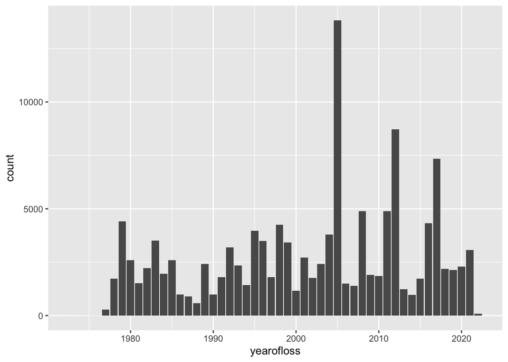

```r
ggplot(data = femaclaim, aes(yearofloss))+geom_bar()
```

##### • What’s the year with the highest number of flood claims? What extreme weather event could explain this pattern? 2005 has the highest number of flood claims due to Hurricane Katrina